# Code for Breast Cancer Pain Study

# 1 Data pre-processing

*Patients selection*.

- Cleaned datasets with new dx_date (initial diagnosis date) was released - R21_Sample_wDxDate.
- Only TN considered. Other states were excluded. (3836 $\rightarrow$ 2628)
- Some duplicated samples were removed.
  - There are 43 duplicated profile keys in the merged data set.
  - e.g. profile key==90006
- There are a lot of missing values in the important variables such as Marital status, Occupation, Primary Payer, POVERTY, and etc. The missing values are systematic rather than just random, for example, if one patient is missing in one variable then it is also missing in the other variables. Therefore, we will only include the patients with no missing values in any of the important covariates.
- missing, NA -> Unknown

*Pain data (PCM) selection*.

- Pain variable (a_CCMA06) observed after at least 60 days prior to dx_date only considered.
- Pain variable (a_CCMA06) within 365 days after the initial diagnosis date (dx_date) has been chosen.
- Mean was taken for Pain by patients.

*Poverty variable collection*.

- “joined_zipcode” file merged to get data about poverty, Blight, unemployment levels for more zip codes.
- Poverty data (from “joined_zipcode”)
  - For poverty variable, group mean used for each zip code.
  - Only 43 zip codes are documented in poverty file. On the other hand, there are 165 zip codes (TN) in Patients file. This produced many missing values for the poverty variable.

*Further data selection*.

```
## Number of patients in the cohort (PatientsData) = 2628
```

```
## Number of patients with Poverty reported = 1502
```

```
## Three outliers excluded
```

```
## NAs in Pain removed (final dataset) = 1191  (NAs = 308 )
```

```
## Number of unique zip code = 33
```

```r
final.data <-
  cdmd.pvt %>%
  select("Pain",
         "Poverty","Blight",
         "Occupation","Marital.status","Insurance.type",
         "Cancer.stage","Chemo",
         "Race","Age",
         "Visits","Metastasis","Histology",
         "Primary.Site.1","Primary.Site.2",
         "HER2","ER","PR")
```

# 2 Table1: Summary of variables

## 2.1 Base

| Table 1. Baseline characteristics, mean and interquartile range of pain intensity, nonparametric rank test | Table 1. Baseline characteristics, mean and interquartile range of pain intensity, nonparametric rank test No. (%) | Table 1. Baseline characteristics, mean and interquartile range of pain intensity, nonparametric rank test Pain, mean [Q1,Q3] | Table 1. Baseline characteristics, mean and interquartile range of pain intensity, nonparametric rank test P-value |
| --- | --- | --- | --- |
| Pain |  |  |  |
| Mean (SD) | 2.05 (2.46) |  |  |
| Median [Min,Max] | 1 [0,10] |  |  |
| Poverty |  |  |  |
| Mean (SD) | 21.56 (12.83) | 1.02 | <.001 |
| Median [Min,Max] | 18.84 [2.47,61.47] |  |  |
| Blight |  |  |  |
| Mean (SD) | 13.85 (6.25) | 1.03 | <.001 |
| Median [Min,Max] | 12.86 [3.24,55.13] |  |  |
| Occupation |  |  |  |
| Employed | 463 (38.9%) | 1.95 [0,3] | 0.016 |
| Retired | 66 (5.5%) | 1.76 [0,2.75] |  |
| Unemployed | 69 (5.8%) | 2.93 [0,5] |  |
| Unknown | 593 (49.8%) | 2.06 [0,3] |  |
| Marital status |  |  |  |
| Married | 413 (34.7%) | 1.7 [0,3] | 0.004 |
| Single | 265 (22.3%) | 2.41 [0,4] |  |
| Divorced | 138 (11.6%) | 2.3 [0,4] |  |
| Unknown | 375 (31.5%) | 2.09 [0,4] |  |
| Insurance type |  |  |  |
| Insurance | 532 (44.7%) | 1.9 [0,3] | 0.047 |
| Medicaid | 289 (24.3%) | 2.29 [0,4] |  |
| Unknown | 370 (31.1%) | 2.08 [0,4] |  |
| Cancer stage |  |  |  |
| 1 | 667 (56%) | 1.74 [0,3] | <.001 |
| 2 | 390 (32.7%) | 2.45 [0,4] |  |
| 3 | 134 (11.3%) | 2.44 [1,4] |  |
| Chemo |  |  |  |
| Treated | 624 (52.4%) | 2.29 [0,4] | <.001 |
| Untreated | 567 (47.6%) | 1.79 [0,3] |  |
| Race |  |  |  |
| White | 634 (53.2%) | 1.67 [0,3] | <.001 |
| Black | 510 (42.8%) | 2.55 [0,4] |  |
| Unknown | 47 (3.9%) | 1.81 [0,3] |  |
| Age |  |  |  |
| Low | 791 (66.4%) | 2.16 [0,4] | 0.052 |
| High | 400 (33.6%) | 1.83 [0,3] |  |

## 2.2 Base + more biomarker variables

[output not shown]

# 3 Plots

*Pain variable (Pain)*:

- For each patient, multiple pains were reported at different dates after their initial diagnosis dates. As a representative value of these multiple observations, average was computed for each patient within the 365-day window.

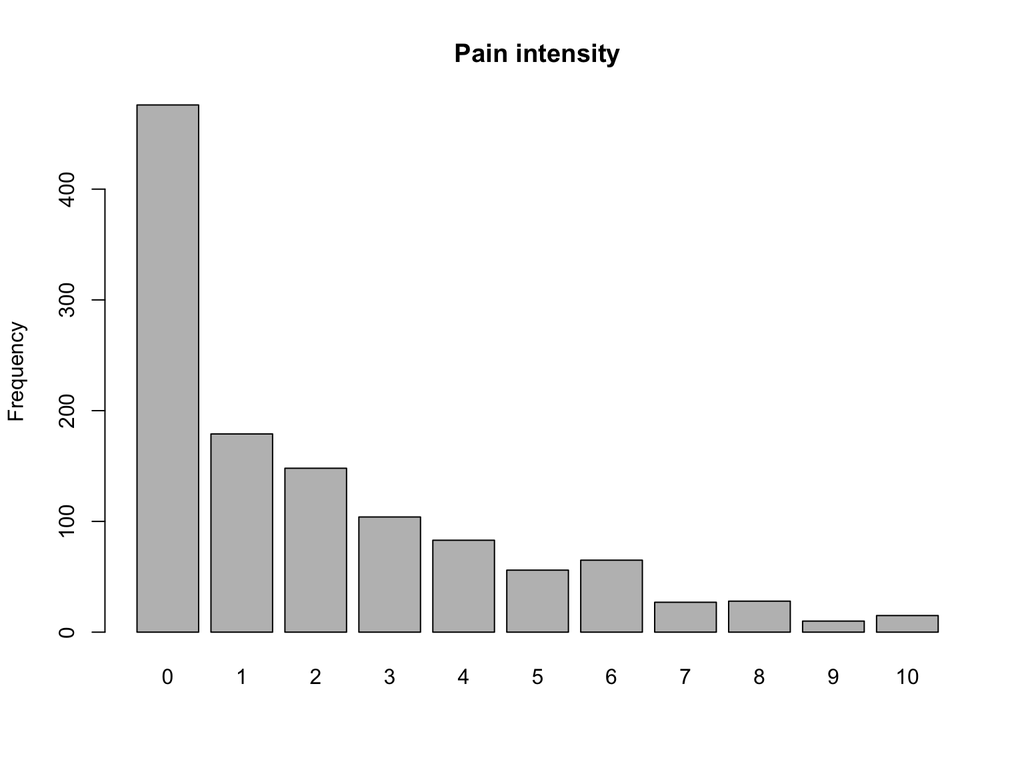

*Poverty variable*:

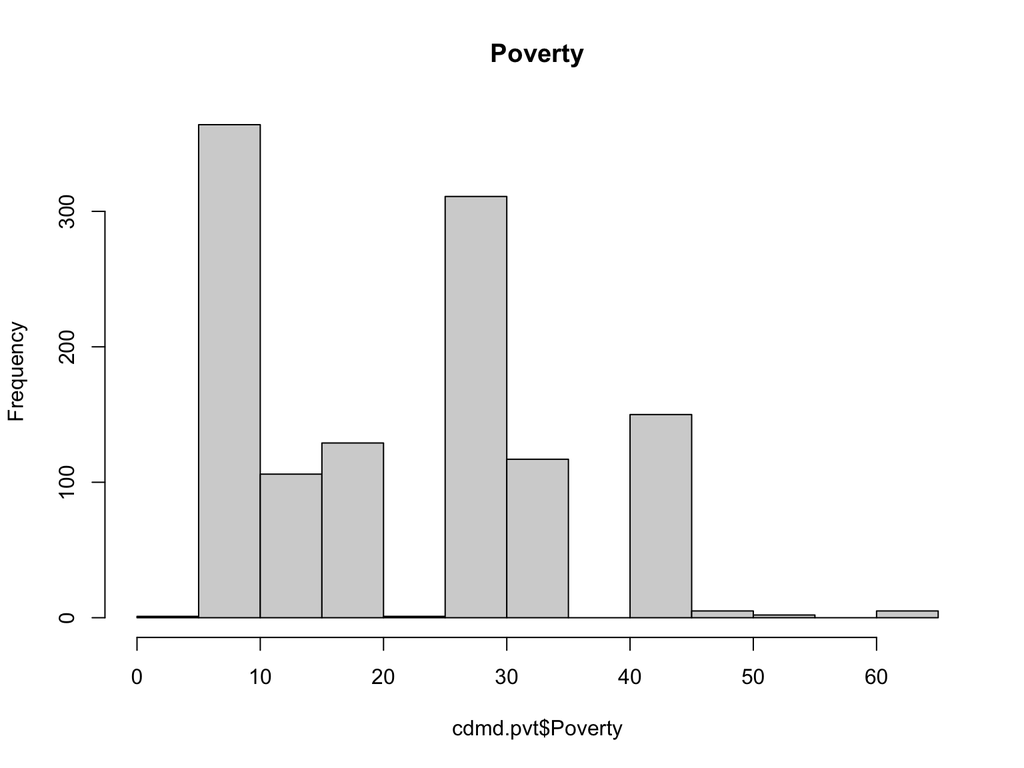

```
## Number of zipcode = 33
```

```
## Median of Poverty = 18.84
```

*Blight variable*:

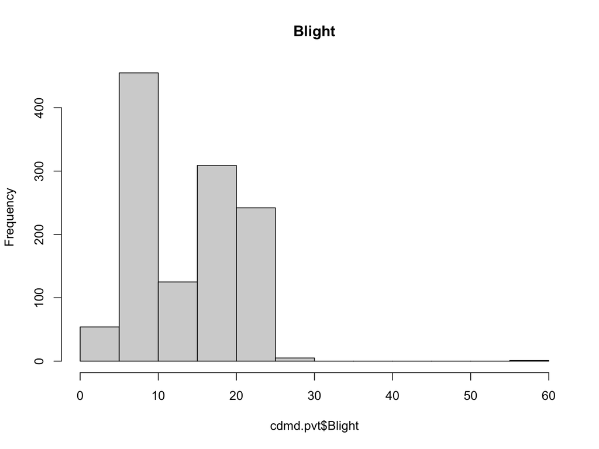

```
## Number of zipcode = 33
```

```
## Median of Blight = 12.856
```

## 3.1 Poverty

- Pain ~ Poverty

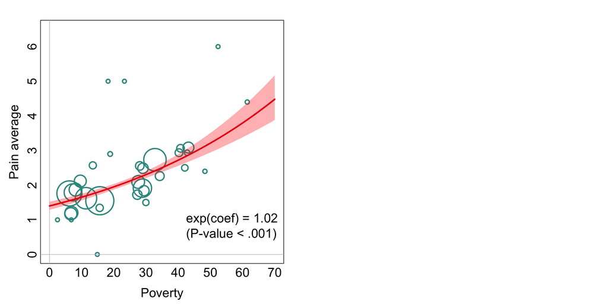

## 3.2 Blight

- Pain ~ Blight

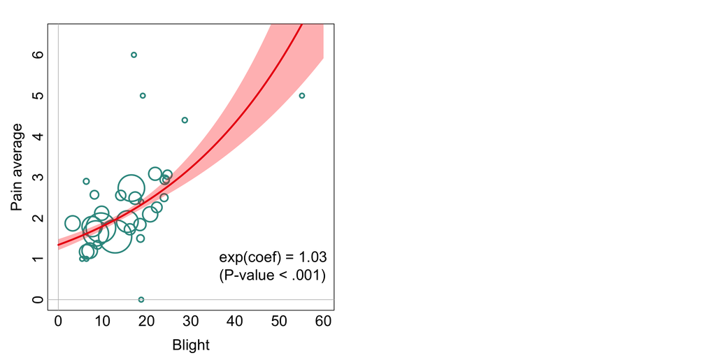

# 4 Table 2: Regression model

## 4.1 Base

### 4.1.1 Poisson count model

|  | Unadjusted Estimate | Unadjusted 95% CI | Unadjusted P-value |  | Adjusted Estimate | Adjusted 95% CI | Adjusted P-value |  | Adjusted Estimate | Adjusted 95% CI | Adjusted P-value |
| --- | --- | --- | --- | --- | --- | --- | --- | --- | --- | --- | --- |
| (Intercept) |  | NA-NA |  |  | 2.24 | 1.952-2.571 | <.001 |  | 2.237 | 1.928-2.595 | <.001 |
| Poverty |  |  |  |  |  |  |  |  |  |  |  |
| Poverty | 1.01 | 1.007-1.013 | <.001 |  | 1.005 | 1.002-1.009 | 0.004 |  |  | NA-NA |  |
| Blight |  |  |  |  |  |  |  |  |  |  |  |
| Blight | 1.016 | 1.01-1.023 | <.001 |  |  | NA-NA |  |  | 1.007 | 1-1.015 | 0.046 |
| Occupation |  |  |  |  |  |  |  |  |  |  |  |
| Employed (reference) |  |  |  |  |  |  |  |  |  |  |  |
| Retired | 0.863 | 0.696-1.069 | 0.178 |  | 0.868 | 0.692-1.089 | 0.221 |  | 0.868 | 0.692-1.089 | 0.222 |
| Unemployed | 1.35 | 1.152-1.583 | <.001 |  | 1.335 | 1.128-1.58 | 0.001 |  | 1.345 | 1.137-1.592 | 0.001 |
| Unknown | 1.065 | 0.971-1.168 | 0.182 |  | 1.106 | 0.984-1.244 | 0.092 |  | 1.111 | 0.988-1.25 | 0.078 |
| Marital status |  |  |  |  |  |  |  |  |  |  |  |
| Married (reference) |  |  |  |  |  |  |  |  |  |  |  |
| Single | 1.32 | 1.177-1.48 | <.001 |  | 1.205 | 1.066-1.362 | 0.003 |  | 1.22 | 1.08-1.378 | 0.001 |
| Divorced | 1.137 | 0.986-1.311 | 0.078 |  | 1.092 | 0.946-1.262 | 0.229 |  | 1.092 | 0.945-1.261 | 0.233 |
| Unknown | 1.105 | 0.989-1.234 | 0.077 |  | 0.997 | 0.773-1.285 | 0.979 |  | 0.987 | 0.765-1.272 | 0.917 |
| Insurance type |  |  |  |  |  |  |  |  |  |  |  |
| Insurance (reference) |  |  |  |  |  |  |  |  |  |  |  |
| Medicaid | 1.063 | 0.957-1.18 | 0.253 |  | 1.073 | 0.947-1.215 | 0.269 |  | 1.07 | 0.944-1.212 | 0.288 |
| Unknown | 1.018 | 0.92-1.125 | 0.731 |  | 1.096 | 0.855-1.406 | 0.47 |  | 1.108 | 0.864-1.421 | 0.419 |
| Cancer stage |  |  |  |  |  |  |  |  |  |  |  |
| 1 (reference) |  |  |  |  |  |  |  |  |  |  |  |
| 2 | 1.118 | 1.021-1.225 | 0.017 |  | 1.05 | 0.951-1.16 | 0.332 |  | 1.052 | 0.953-1.162 | 0.315 |
| 3 | 0.978 | 0.857-1.117 | 0.746 |  | 0.861 | 0.746-0.994 | 0.042 |  | 0.862 | 0.746-0.996 | 0.043 |
| Chemo |  |  |  |  |  |  |  |  |  |  |  |
| Treated (reference) |  |  |  |  |  |  |  |  |  |  |  |
| Untreated | 1.01 | 0.926-1.101 | 0.824 |  | 1.066 | 0.97-1.172 | 0.186 |  | 1.065 | 0.969-1.171 | 0.189 |
| Race |  |  |  |  |  |  |  |  |  |  |  |
| White (reference) |  |  |  |  |  |  |  |  |  |  |  |
| Black | 1.319 | 1.208-1.439 | <.001 |  | 1.202 | 1.084-1.333 | 0.001 |  | 1.235 | 1.117-1.367 | <.001 |
| Unknown | 1.271 | 1.006-1.606 | 0.045 |  | 1.164 | 0.916-1.479 | 0.214 |  | 1.176 | 0.926-1.494 | 0.184 |
| Age |  |  |  |  |  |  |  |  |  |  |  |
| Low (reference) |  |  |  |  |  |  |  |  |  |  |  |
| High | 0.873 | 0.795-0.959 | 0.005 |  | 0.873 | 0.784-0.973 | 0.014 |  | 0.877 | 0.787-0.977 | 0.018 |

### 4.1.2 Inflation model

|  | Unadjusted Estimate | Unadjusted 95% CI | Unadjusted P-value |  | Adjusted Estimate | Adjusted 95% CI | Adjusted P-value |  | Adjusted Estimate | Adjusted 95% CI | Adjusted P-value |
| --- | --- | --- | --- | --- | --- | --- | --- | --- | --- | --- | --- |
| (Intercept) |  | NA-NA |  |  | 1.139 | 1.692-0.767 | 0.52 |  | 1.004 | 1.548-0.651 | 0.987 |
| Poverty |  |  |  |  |  |  |  |  |  |  |  |
| Poverty | 1.018 | 1.029-1.008 | <.001 |  | 1.015 | 1.028-1.003 | 0.011 |  |  | NA-NA |  |
| Blight |  |  |  |  |  |  |  |  |  |  |  |
| Blight | 1.037 | 1.058-1.016 | <.001 |  |  | NA-NA |  |  | 1.033 | 1.057-1.008 | 0.008 |
| Occupation |  |  |  |  |  |  |  |  |  |  |  |
| Employed (reference) |  |  |  |  |  |  |  |  |  |  |  |
| Retired | 1.12 | 2.041-0.614 | 0.711 |  | 0.996 | 1.972-0.503 | 0.991 |  | 0.99 | 1.961-0.5 | 0.978 |
| Unemployed | 1.353 | 2.37-0.772 | 0.29 |  | 0.862 | 1.595-0.465 | 0.636 |  | 0.86 | 1.592-0.464 | 0.631 |
| Unknown | 0.967 | 1.263-0.742 | 0.808 |  | 0.757 | 1.082-0.53 | 0.127 |  | 0.755 | 1.079-0.528 | 0.123 |
| Marital status |  |  |  |  |  |  |  |  |  |  |  |
| Married (reference) |  |  |  |  |  |  |  |  |  |  |  |
| Single | 1.188 | 1.656-0.852 | 0.311 |  | 0.856 | 1.248-0.587 | 0.419 |  | 0.86 | 1.252-0.59 | 0.431 |
| Divorced | 1.6 | 2.488-1.032 | 0.036 |  | 1.431 | 2.294-0.892 | 0.137 |  | 1.429 | 2.288-0.89 | 0.14 |
| Unknown | 1.309 | 1.783-0.961 | 0.088 |  | 2.222 | 5.181-0.951 | 0.065 |  | 2.193 | 5.128-0.94 | 0.069 |
| Insurance type |  |  |  |  |  |  |  |  |  |  |  |
| Insurance (reference) |  |  |  |  |  |  |  |  |  |  |  |
| Medicaid | 1.397 | 1.916-1.017 | 0.039 |  | 1.779 | 2.717-1.164 | 0.008 |  | 1.776 | 2.71-1.161 | 0.008 |
| Unknown | 1.202 | 1.605-0.899 | 0.214 |  | 0.776 | 1.786-0.337 | 0.551 |  | 0.784 | 1.802-0.341 | 0.566 |
| Cancer stage |  |  |  |  |  |  |  |  |  |  |  |
| 1 (reference) |  |  |  |  |  |  |  |  |  |  |  |
| 2 | 1.866 | 2.463-1.412 | <.001 |  | 1.605 | 2.183-1.176 | 0.003 |  | 1.616 | 2.198-1.185 | 0.002 |
| 3 | 3.077 | 5.051-1.876 | <.001 |  | 2.747 | 4.975-1.511 | 0.001 |  | 2.786 | 5.051-1.529 | 0.001 |
| Chemo |  |  |  |  |  |  |  |  |  |  |  |
| Treated (reference) |  |  |  |  |  |  |  |  |  |  |  |
| Untreated | 0.512 | 0.659-0.398 | <.001 |  | 0.619 | 0.823-0.466 | 0.001 |  | 0.621 | 0.826-0.467 | 0.001 |
| Race |  |  |  |  |  |  |  |  |  |  |  |
| White (reference) |  |  |  |  |  |  |  |  |  |  |  |
| Black | 1.497 | 1.942-1.155 | 0.002 |  | 1.031 | 1.416-0.75 | 0.853 |  | 1.055 | 1.437-0.775 | 0.732 |
| Unknown | 0.704 | 1.3-0.381 | 0.262 |  | 0.707 | 1.35-0.37 | 0.293 |  | 0.71 | 1.353-0.372 | 0.298 |
| Age |  |  |  |  |  |  |  |  |  |  |  |
| Low (reference) |  |  |  |  |  |  |  |  |  |  |  |
| High | 0.917 | 1.193-0.704 | 0.519 |  | 0.786 | 1.105-0.558 | 0.166 |  | 0.785 | 1.105-0.558 | 0.165 |

## 4.2 Base + more biomarker variables

### 4.2.1 Poisson count model:

|  | Unadjusted Estimate | Unadjusted 95% CI | Unadjusted P-value |  | Adjusted Estimate | Adjusted 95% CI | Adjusted P-value |  | Adjusted Estimate | Adjusted 95% CI | Adjusted P-value |
| --- | --- | --- | --- | --- | --- | --- | --- | --- | --- | --- | --- |
| (Intercept) |  | NA-NA |  |  | 3.382 | 2.267-5.044 | <.001 |  | 3.325 | 2.223-4.973 | <.001 |
| Poverty |  |  |  |  |  |  |  |  |  |  |  |
| Poverty | 1.01 | 1.007-1.013 | <.001 |  | 1.006 | 1.002-1.01 | 0.002 |  |  | NA-NA |  |
| Blight |  |  |  |  |  |  |  |  |  |  |  |
| Blight | 1.016 | 1.01-1.023 | <.001 |  |  | NA-NA |  |  | 1.01 | 1.002-1.017 | 0.01 |
| Occupation |  |  |  |  |  |  |  |  |  |  |  |
| Employed (reference) |  |  |  |  |  |  |  |  |  |  |  |
| Retired | 0.863 | 0.696-1.069 | 0.178 |  | 0.9 | 0.712-1.138 | 0.38 |  | 0.902 | 0.713-1.14 | 0.388 |
| Unemployed | 1.35 | 1.152-1.583 | <.001 |  | 1.355 | 1.132-1.621 | 0.001 |  | 1.367 | 1.143-1.636 | 0.001 |
| Unknown | 1.065 | 0.971-1.168 | 0.182 |  | 1.048 | 0.926-1.186 | 0.457 |  | 1.054 | 0.931-1.193 | 0.404 |
| Marital status |  |  |  |  |  |  |  |  |  |  |  |
| Married (reference) |  |  |  |  |  |  |  |  |  |  |  |
| Single | 1.32 | 1.177-1.48 | <.001 |  | 1.193 | 1.051-1.354 | 0.006 |  | 1.201 | 1.059-1.363 | 0.004 |
| Divorced | 1.137 | 0.986-1.311 | 0.078 |  | 1.087 | 0.935-1.265 | 0.279 |  | 1.083 | 0.931-1.261 | 0.302 |
| Unknown | 1.105 | 0.989-1.234 | 0.077 |  | 1.033 | 0.772-1.381 | 0.829 |  | 1.022 | 0.764-1.367 | 0.883 |
| Insurance type |  |  |  |  |  |  |  |  |  |  |  |
| Insurance (reference) |  |  |  |  |  |  |  |  |  |  |  |
| Medicaid | 1.063 | 0.957-1.18 | 0.253 |  | 1.027 | 0.904-1.166 | 0.685 |  | 1.025 | 0.902-1.164 | 0.704 |
| Unknown | 1.018 | 0.92-1.125 | 0.731 |  | 1.064 | 0.718-1.576 | 0.759 |  | 1.074 | 0.725-1.591 | 0.722 |
| Cancer stage |  |  |  |  |  |  |  |  |  |  |  |
| 1 (reference) |  |  |  |  |  |  |  |  |  |  |  |
| 2 | 1.118 | 1.021-1.225 | 0.017 |  | 1.1 | 0.993-1.218 | 0.068 |  | 1.102 | 0.995-1.22 | 0.063 |
| 3 | 0.978 | 0.857-1.117 | 0.746 |  | 0.87 | 0.748-1.011 | 0.07 |  | 0.872 | 0.75-1.014 | 0.075 |
| Chemo |  |  |  |  |  |  |  |  |  |  |  |
| Treated (reference) |  |  |  |  |  |  |  |  |  |  |  |
| Untreated | 1.01 | 0.926-1.101 | 0.824 |  | 1.024 | 0.924-1.135 | 0.647 |  | 1.024 | 0.924-1.134 | 0.655 |
| Visits |  |  |  |  |  |  |  |  |  |  |  |
| Visits | 0.991 | 0.981-1 | 0.054 |  | 0.99 | 0.979-1.002 | 0.091 |  | 0.99 | 0.979-1.001 | 0.084 |
| Metastasis |  |  |  |  |  |  |  |  |  |  |  |
| No (reference) |  |  |  |  |  |  |  |  |  |  |  |
| Yes | 0.945 | 0.868-1.028 | 0.189 |  | 0.942 | 0.862-1.031 | 0.194 |  | 0.943 | 0.862-1.031 | 0.195 |
| Race |  |  |  |  |  |  |  |  |  |  |  |
| White (reference) |  |  |  |  |  |  |  |  |  |  |  |
| Black | 1.319 | 1.208-1.439 | <.001 |  | 1.175 | 1.057-1.306 | 0.003 |  | 1.201 | 1.083-1.332 | 0.001 |
| Unknown | 1.271 | 1.006-1.606 | 0.045 |  | 1.104 | 0.862-1.415 | 0.432 |  | 1.115 | 0.871-1.427 | 0.389 |
| Age |  |  |  |  |  |  |  |  |  |  |  |
| Low (reference) |  |  |  |  |  |  |  |  |  |  |  |
| High | 0.873 | 0.795-0.959 | 0.005 |  | 0.866 | 0.776-0.968 | 0.011 |  | 0.868 | 0.777-0.97 | 0.013 |
| Histology |  |  |  |  |  |  |  |  |  |  |  |
| ductal (reference) |  |  |  |  |  |  |  |  |  |  |  |
| lobular | 0.958 | 0.798-1.149 | 0.643 |  | 1.036 | 0.857-1.253 | 0.714 |  | 1.042 | 0.861-1.26 | 0.675 |
| Other | 1.353 | 1.024-1.79 | 0.034 |  | 1.298 | 0.969-1.737 | 0.08 |  | 1.293 | 0.966-1.731 | 0.084 |
| Unknown | 0.99 | 0.901-1.089 | 0.843 |  | 0.976 | 0.543-1.755 | 0.936 |  | 0.972 | 0.54-1.749 | 0.924 |
| Primary Site 1 |  |  |  |  |  |  |  |  |  |  |  |
| Lower (reference) |  |  |  |  |  |  |  |  |  |  |  |
| Central | 1.269 | 0.997-1.616 | 0.053 |  | 1.311 | 0.953-1.804 | 0.096 |  | 1.339 | 0.974-1.84 | 0.072 |
| Upper | 0.987 | 0.839-1.161 | 0.877 |  | 0.91 | 0.762-1.087 | 0.298 |  | 0.916 | 0.767-1.094 | 0.332 |
| Unknown | 1.086 | 0.932-1.265 | 0.292 |  | 1.225 | 0.958-1.568 | 0.106 |  | 1.249 | 0.978-1.594 | 0.075 |
| Primary Site 2 |  |  |  |  |  |  |  |  |  |  |  |
| Inner (reference) |  |  |  |  |  |  |  |  |  |  |  |
| Midline | 0.928 | 0.639-1.349 | 0.697 |  | 0.774 | 0.503-1.191 | 0.244 |  | 0.767 | 0.499-1.179 | 0.227 |
| Outer | 1.046 | 0.892-1.228 | 0.579 |  | 1.143 | 0.957-1.365 | 0.142 |  | 1.151 | 0.964-1.375 | 0.121 |
| Overlapping | 1.071 | 0.872-1.316 | 0.512 |  | 0.82 | 0.616-1.092 | 0.174 |  | 0.82 | 0.617-1.091 | 0.173 |
| Unknown | 1.127 | 0.969-1.311 | 0.121 |  | 0.967 | 0.758-1.235 | 0.789 |  | 0.965 | 0.757-1.23 | 0.774 |
| HER2 |  |  |  |  |  |  |  |  |  |  |  |
| Negative.Normal (reference) |  |  |  |  |  |  |  |  |  |  |  |
| Positive.Elevated | 0.801 | 0.681-0.941 | 0.007 |  | 0.798 | 0.674-0.946 | 0.009 |  | 0.8 | 0.675-0.948 | 0.01 |
| Unknown | 0.901 | 0.824-0.985 | 0.022 |  | 0.845 | 0.718-0.994 | 0.043 |  | 0.844 | 0.717-0.993 | 0.041 |
| ER |  |  |  |  |  |  |  |  |  |  |  |
| Negative.Normal (reference) |  |  |  |  |  |  |  |  |  |  |  |
| Positive.Elevated | 0.749 | 0.543-1.035 | 0.08 |  | 0.692 | 0.488-0.981 | 0.039 |  | 0.683 | 0.482-0.969 | 0.033 |
| Unknown | 0.738 | 0.532-1.024 | 0.069 |  | 0.514 | 0.198-1.329 | 0.17 |  | 0.5 | 0.193-1.299 | 0.155 |
| PR |  |  |  |  |  |  |  |  |  |  |  |
| Negative.Normal (reference) |  |  |  |  |  |  |  |  |  |  |  |
| Positive.Elevated | 1.034 | 0.9-1.188 | 0.64 |  | 1.058 | 0.907-1.234 | 0.473 |  | 1.056 | 0.905-1.231 | 0.489 |
| Unknown | 1.007 | 0.868-1.167 | 0.931 |  | 1.528 | 0.697-3.35 | 0.29 |  | 1.551 | 0.706-3.407 | 0.275 |

### 4.2.2 Inflation model:

|  | Unadjusted Estimate | Unadjusted 95% CI | Unadjusted P-value |  | Adjusted Estimate | Adjusted 95% CI | Adjusted P-value |  | Adjusted Estimate | Adjusted 95% CI | Adjusted P-value |
| --- | --- | --- | --- | --- | --- | --- | --- | --- | --- | --- | --- |
| (Intercept) |  | NA-NA |  |  | 0.404 | 1.647-0.099 | 0.206 |  | 0.376 | 1.546-0.091 | 0.175 |
| Poverty |  |  |  |  |  |  |  |  |  |  |  |
| Poverty | 1.018 | 1.029-1.008 | <.001 |  | 1.015 | 1.028-1.003 | 0.015 |  |  | NA-NA |  |
| Blight |  |  |  |  |  |  |  |  |  |  |  |
| Blight | 1.037 | 1.058-1.016 | <.001 |  |  | NA-NA |  |  | 1.031 | 1.056-1.006 | 0.016 |
| Occupation |  |  |  |  |  |  |  |  |  |  |  |
| Employed (reference) |  |  |  |  |  |  |  |  |  |  |  |
| Retired | 1.12 | 2.041-0.614 | 0.711 |  | 0.968 | 1.961-0.478 | 0.928 |  | 0.964 | 1.949-0.476 | 0.919 |
| Unemployed | 1.353 | 2.37-0.772 | 0.29 |  | 0.844 | 1.637-0.435 | 0.615 |  | 0.848 | 1.645-0.438 | 0.626 |
| Unknown | 0.967 | 1.263-0.742 | 0.808 |  | 0.787 | 1.152-0.538 | 0.218 |  | 0.786 | 1.151-0.537 | 0.216 |
| Marital status |  |  |  |  |  |  |  |  |  |  |  |
| Married (reference) |  |  |  |  |  |  |  |  |  |  |  |
| Single | 1.188 | 1.656-0.852 | 0.311 |  | 0.898 | 1.33-0.607 | 0.59 |  | 0.907 | 1.342-0.614 | 0.627 |
| Divorced | 1.6 | 2.488-1.032 | 0.036 |  | 1.431 | 2.347-0.871 | 0.157 |  | 1.441 | 2.37-0.877 | 0.149 |
| Unknown | 1.309 | 1.783-0.961 | 0.088 |  | 2.353 | 6.993-0.791 | 0.124 |  | 2.342 | 6.993-0.787 | 0.126 |
| Insurance type |  |  |  |  |  |  |  |  |  |  |  |
| Insurance (reference) |  |  |  |  |  |  |  |  |  |  |  |
| Medicaid | 1.397 | 1.916-1.017 | 0.039 |  | 1.873 | 2.899-1.211 | 0.005 |  | 1.862 | 2.882-1.203 | 0.005 |
| Unknown | 1.202 | 1.605-0.899 | 0.214 |  | 1.001 | 3.448-0.29 | 0.998 |  | 1.013 | 3.484-0.294 | 0.983 |
| Cancer stage |  |  |  |  |  |  |  |  |  |  |  |
| 1 (reference) |  |  |  |  |  |  |  |  |  |  |  |
| 2 | 1.866 | 2.463-1.412 | <.001 |  | 1.466 | 2.028-1.062 | 0.02 |  | 1.479 | 2.041-1.071 | 0.018 |
| 3 | 3.077 | 5.051-1.876 | <.001 |  | 2.347 | 4.505-1.222 | 0.01 |  | 2.353 | 4.505-1.23 | 0.01 |
| Chemo |  |  |  |  |  |  |  |  |  |  |  |
| Treated (reference) |  |  |  |  |  |  |  |  |  |  |  |
| Untreated | 0.512 | 0.659-0.398 | <.001 |  | 0.914 | 1.282-0.652 | 0.603 |  | 0.912 | 1.277-0.65 | 0.59 |
| Visits |  |  |  |  |  |  |  |  |  |  |  |
| Visits | 1.122 | 1.163-1.083 | <.001 |  | 1.112 | 1.168-1.059 | <.001 |  | 1.11 | 1.166-1.058 | <.001 |
| Metastasis |  |  |  |  |  |  |  |  |  |  |  |
| No (reference) |  |  |  |  |  |  |  |  |  |  |  |
| Yes | 1.453 | 1.866-1.133 | 0.003 |  | 1.115 | 1.481-0.839 | 0.453 |  | 1.109 | 1.473-0.835 | 0.474 |
| Race |  |  |  |  |  |  |  |  |  |  |  |
| White (reference) |  |  |  |  |  |  |  |  |  |  |  |
| Black | 1.497 | 1.942-1.155 | 0.002 |  | 1.04 | 1.443-0.75 | 0.815 |  | 1.075 | 1.477-0.782 | 0.656 |
| Unknown | 0.704 | 1.3-0.381 | 0.262 |  | 0.771 | 1.515-0.392 | 0.451 |  | 0.777 | 1.527-0.395 | 0.464 |
| Age |  |  |  |  |  |  |  |  |  |  |  |
| Low (reference) |  |  |  |  |  |  |  |  |  |  |  |
| High | 0.917 | 1.193-0.704 | 0.519 |  | 0.918 | 1.309-0.644 | 0.638 |  | 0.919 | 1.311-0.645 | 0.64 |
| Histology |  |  |  |  |  |  |  |  |  |  |  |
| ductal (reference) |  |  |  |  |  |  |  |  |  |  |  |
| lobular | 0.723 | 1.163-0.449 | 0.181 |  | 0.668 | 1.155-0.387 | 0.149 |  | 0.675 | 1.164-0.391 | 0.158 |
| Other | 1.242 | 3.436-0.449 | 0.676 |  | 1.209 | 3.584-0.408 | 0.732 |  | 1.183 | 3.497-0.4 | 0.761 |
| Unknown | 1.052 | 1.389-0.796 | 0.725 |  | 0.492 | 3.745-0.065 | 0.493 |  | 0.486 | 3.676-0.064 | 0.485 |
| Primary Site 1 |  |  |  |  |  |  |  |  |  |  |  |
| Lower (reference) |  |  |  |  |  |  |  |  |  |  |  |
| Central | 1.359 | 2.907-0.637 | 0.428 |  | 1.555 | 4.31-0.561 | 0.396 |  | 1.565 | 4.348-0.563 | 0.391 |
| Upper | 1.119 | 1.736-0.72 | 0.618 |  | 1.054 | 1.754-0.634 | 0.84 |  | 1.047 | 1.742-0.629 | 0.859 |
| Unknown | 1.263 | 1.919-0.831 | 0.275 |  | 1.321 | 2.77-0.631 | 0.46 |  | 1.333 | 2.801-0.634 | 0.448 |
| Primary Site 2 |  |  |  |  |  |  |  |  |  |  |  |
| Inner (reference) |  |  |  |  |  |  |  |  |  |  |  |
| Midline | 1.087 | 2.809-0.42 | 0.864 |  | 0.67 | 2.208-0.203 | 0.51 |  | 0.682 | 2.252-0.206 | 0.529 |
| Outer | 1.346 | 2.058-0.881 | 0.17 |  | 1.229 | 2.012-0.749 | 0.416 |  | 1.241 | 2.033-0.758 | 0.391 |
| Overlapping | 1.195 | 2.079-0.685 | 0.531 |  | 0.943 | 2.268-0.393 | 0.896 |  | 0.947 | 2.278-0.394 | 0.903 |
| Unknown | 1.453 | 2.169-0.973 | 0.068 |  | 1.03 | 2.11-0.503 | 0.935 |  | 1.035 | 2.128-0.504 | 0.924 |
| HER2 |  |  |  |  |  |  |  |  |  |  |  |
| Negative.Normal (reference) |  |  |  |  |  |  |  |  |  |  |  |
| Positive.Elevated | 1.12 | 1.757-0.713 | 0.623 |  | 0.646 | 1.099-0.38 | 0.107 |  | 0.648 | 1.103-0.381 | 0.11 |
| Unknown | 1.122 | 1.46-0.864 | 0.386 |  | 0.958 | 1.567-0.586 | 0.864 |  | 0.956 | 1.562-0.585 | 0.857 |
| ER |  |  |  |  |  |  |  |  |  |  |  |
| Negative.Normal (reference) |  |  |  |  |  |  |  |  |  |  |  |
| Positive.Elevated | 0.861 | 2.667-0.278 | 0.796 |  | 1.302 | 4.673-0.362 | 0.686 |  | 1.258 | 4.505-0.351 | 0.725 |
| Unknown | 0.95 | 2.976-0.303 | 0.93 |  | 0 | Inf-0 | 0.987 |  | 0 | Inf-0 | 0.987 |
| PR |  |  |  |  |  |  |  |  |  |  |  |
| Negative.Normal (reference) |  |  |  |  |  |  |  |  |  |  |  |
| Positive.Elevated | 0.788 | 1.202-0.517 | 0.269 |  | 0.812 | 1.357-0.487 | 0.427 |  | 0.815 | 1.361-0.489 | 0.434 |
| Unknown | 0.912 | 1.433-0.581 | 0.69 |  | Inf | Inf-0 | 0.987 |  | Inf | Inf-0 | 0.987 |